# CampR control de calidad en campañas de arrastre

Fran Velasco

2022-11-22

Este documento R Markdown. resume y propone un protolo para realiar la comprobación de errores en los datos recogidos y tecleados a lo largo de una campaña de arrastre con datos almacenados con las bases de datos de **CAMP 12** Harbour Windows 10 version.

El protocolo debe incluir la revisión de:

### Pescas: datos en el fichero `lancesXXX.dbf`

La revisión puede incluir un mapa con la distribución de los lances que permite encontrar errores de bulto rápidamente. La función `armap.camp(camp="N12",dns="Cant")` permite incluir el número del lance con `Nlans=TRUE` que también puede ayudar a localizar errores

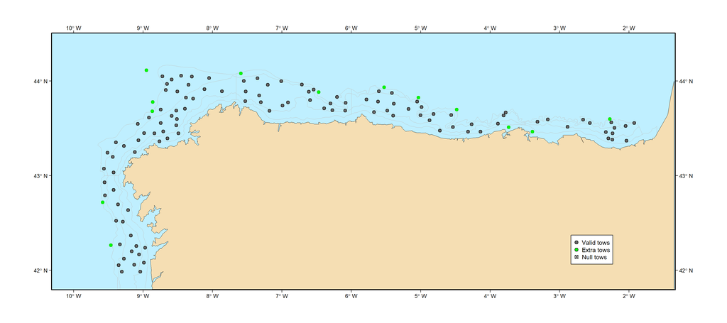

```r
armap.camp("N12","Cant")
```

La función `qcdistlan.camp` permite ver errores en la distancia recorrida y la velocidad incluida en los datos y su relación, además de la duración del lance y el rumbo.

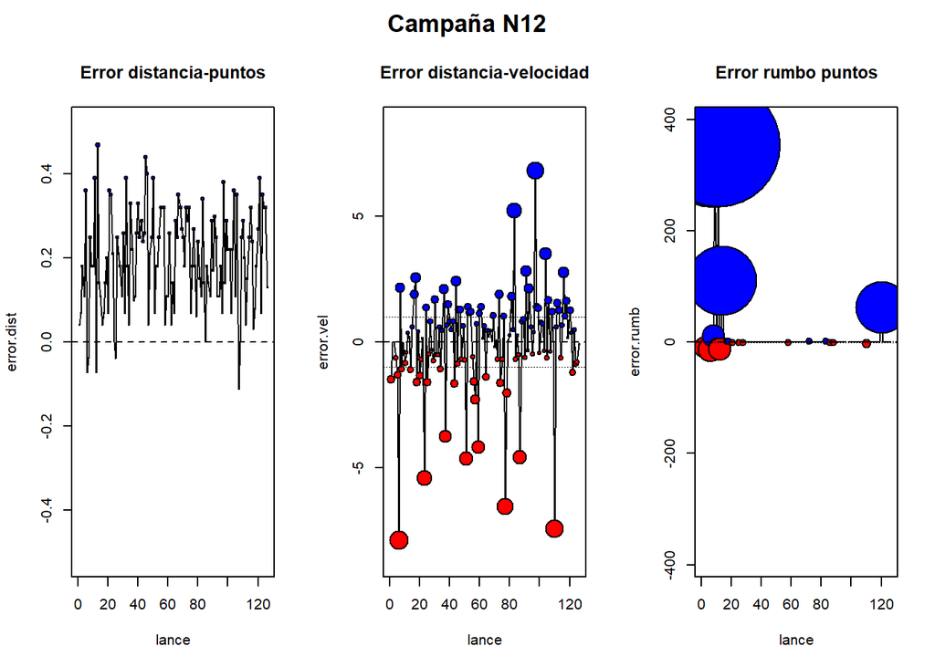

```
##     camp lance recorrido dist.hf dist.vel velocidad mins rumbo  rumb vel.dist
## 1    N12     2      2778    2780     2778       3.0   30    33  22.9      3.0
## 9    N12     6      2814    2812     2593       2.8   30   330 315.8      3.0
## 14   N12     8      2808    2815     2778       3.0   30   208 219.5      3.0
## 8    N12     9      2778    2783     2778       3.0   30     7 359.1      3.0
## 21   N12    11      3595    3609     3580       2.9   40     3 358.0      2.9
## 18   N12    12      2768    2766     2778       3.0   30    30  18.2      3.0
## 19   N12    14      2809    2813     2778       3.0   30    30 140.5      3.0
## 73   N12    77      2972    2980     2778       3.0   30    98  97.5      3.2
## 104  N12    97      2601    2611     2778       3.0   30    NA  91.2      2.8
## 122  N12   110      3101    3110     2871       3.1   30   295 293.0      3.4
## 96   N12   120      2926    2934     2963       3.2   30   181 243.2      3.2
##     error.dist error.vel error.rumb
## 1         0.07      0.00        -10
## 9        -0.07     -7.85        -14
## 14        0.25     -1.07         12
## 8         0.18      0.00        352
## 21        0.39     -0.42        355
## 18       -0.07      0.36        -12
## 19        0.14     -1.10        110
## 73        0.27     -6.53          0
## 104       0.38      6.81         NA
## 122       0.29     -7.42         -2
## 96        0.27      1.26         62
```

```r
qcdistlan.camp("N12","Cant",todos=FALSE,pc.error=2)
```

### Funcionamiento del arte (análisis del `log` del ITI, MARPORT, SCANMAR…)

Los datos se pueden tomar directamente del equipo a través de los telegramas que se pasan al `PescaWin` y procesarlo: preparar ejemplos a partir de un archivo de `log` del MARPORT u otro monitor de funcionamiento del aparejo.

### Revisión de capturas - pesos según relación LW

La función `qcLW.camp(1,51,"N12","Cant")` produce un gráfico con los pesos por lance en función de la captura y el peso estimado para esa captura a partir de la distribución de tallas medidas. El error respecto a la mediana permite también ver qué lances dan error por categoría. `qcLWbucl.camp` permite revisar todas las especies de la campaña sucesivamente, y con `out.dat=TRUE` produce una tabla con todos los errores de todas las especies de peces sin necesidad de revisar todos los gráficos.

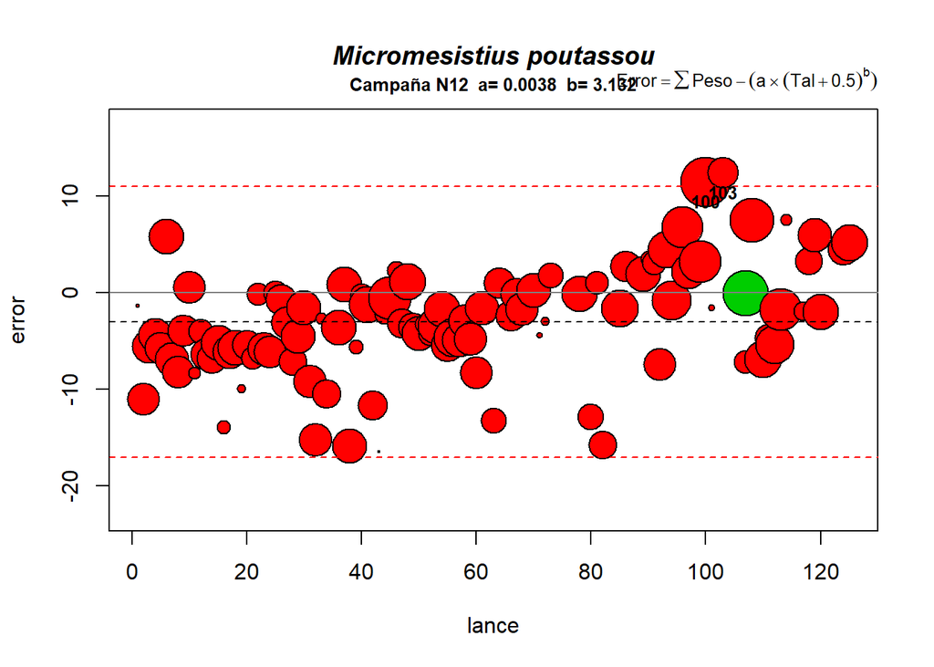

```
##    lance    estim cate  obs   n    error
## 86   100 5419.900    1 4865 264 11.40596
## 88   103 2584.753    1 2300 103 12.38059
```

### Revisión de tallas y sexos

La función `qcdtall.camp(gr,esp,"N12","Cant",lance=xxx)` permite revisar la distribución de tallas medida para el lance `xxx` junto con las categorías medidas y los factores de ponderación `captura/muestra` para cada categoría, añadiendo cual habría sido el tamaño de muestra suficiente en función del rango de tallas encontrado.

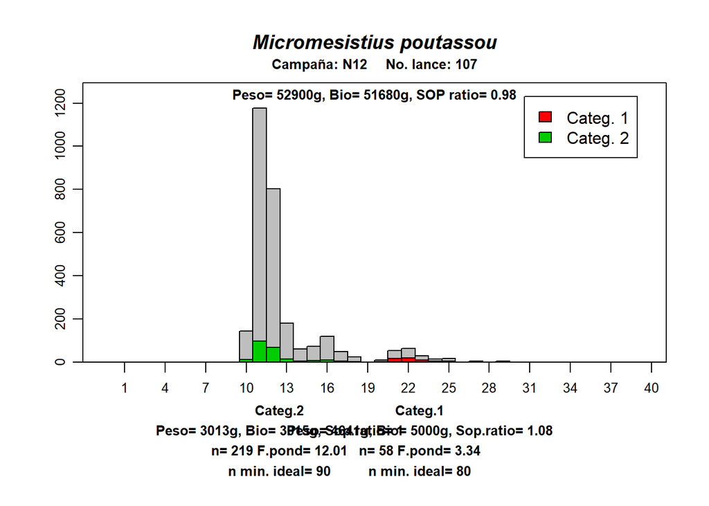

La función `qcdtallrev.camp` permite sacar las distribuciones de todas las especies y lances, se puede cortar pulsando `ESCAPE` en cualquier momento, y resulta muy útil para revisar posibles datos de especies con identificación de sexos en **especies que habitualmente no se miden por sexos**.

### Revisión de medición de tallas para todos los peces

La función `qcTalPez.lan(camp,dns="Cant",lan,gr=1)` revisa que haya datos de tallas en el fichero de tallas `NTALLxxx.DBF` para todas las especies registradas en el fichero `FAUNAXXX.DBF` y viceversa, localizando especies que no se han medido en un lance, o especies que se han medido pero no se ha registrado el peso de captura y discordancias entre inviduos medidos en `NTALLxxx.DBF` y los registrados para el lance correspondiente en `FAUNAxxx.DBF`.

```r
qcTalPez.lan("P18",dns="Porc",16,gr=1)
```

Provisionalmente existe una función `qcTalPez.camp(camp,dns,gr)` que recorre todos los lances de la campaña buscando errores, habrá que mejorarla, porque va haciendo pausas entre lances y no es una salida muy *amigable*

### Revisión de edades (post campaña y con otolitos leídos)

La función `grafedtal.camp` permite ver la composción por edades de cada talla, identificando posibles errores de tecleo y dando una imágen de la composición por edades de la captura en el lance.

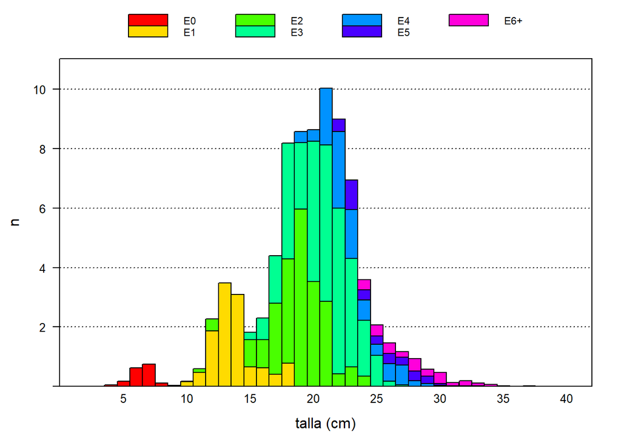

La función `GetAlk.camp(gr,esp,camp,dns,plus)` permite sacar la clave talla edad utilizada para convertir los datos de tallas en la distribución por edades variando como sea necesario la `edad plus` y utilizar una clave alternativa si acaso.